# Spike and Slab

# Quick recap of OLS: deriving optimal coefficients through least squares

There are many options to choose for the intercept (alpha) and the slope (beta) to best a line that best fits the data, but we want to find the ones that best fit the data:

```r
require(plotly)
set.seed(1)
X = 0:5
y = 5 + 2*X + runif(6,-0.5,1)
plot_ly(type='scatter',mode='lines') %>%
  add_trace(x=X,y=y,mode='markers',name='Observed data') %>%
  add_trace(x=X,y=1+1*X,name='alpha=1,beta=0.5') %>%
  add_trace(x=X,y=5+1*X,name='alpha=5,beta=0.5') %>%
  add_trace(x=X,y=9+1*X,name='alpha=9,beta=0.5') %>%
  add_trace(x=X,y=1+2*X,name='alpha=1,beta=2') %>%
  add_trace(x=X,y=5+2*X,name='alpha=5,beta=2') %>%
  add_trace(x=X,y=9+2*X,name='alpha=9,beta=2') %>%
  add_trace(x=X,y=1+4*X,name='alpha=1,beta=4') %>%
  add_trace(x=X,y=5+4*X,name='alpha=5,beta=4') %>%
  add_trace(x=X,y=9+4*X,name='alpha=9,beta=4') %>%
  layout(xaxis=list(title='X'), yaxis=list(title='y'))
```

[interactive chart not shown]

We can see that the choices of alpha and beta that minimize the sum of squared residuals are 5 and 2 respectively:

```r
alpha_options <- seq(3,7,1) # seq(4,6,1) #
beta_options <- 2^seq(0,2,0.5) # 2^seq(0.5,1.5,0.5) #
graph_options <- "plot_ly(type='scatter',mode='lines') %>% add_trace(x=X,y=y,mode='markers',name='Observed data') %>% "
cost_matrix <- matrix(nrow=length(alpha_options),ncol=length(beta_options),dimnames = list(alpha_options, beta_options))
for(alpha in 1:length(alpha_options)) {
  for(beta in 1:length(beta_options)) {
    graph_options <- paste0(graph_options, paste0(" add_trace(x=X,y=",alpha_options[alpha],"+",beta_options[beta],"*X",",name='alpha=",alpha_options[alpha],",beta=",round(beta_options[beta],1),"') %>%  \n"))
    cost_matrix[alpha,beta] <- sum((y-alpha_options[alpha]-beta_options[beta]*X)^2)
  }
}
graph_options <- paste0(graph_options, ' layout()')
# eval(parse(text=graph_options))
plot_ly(x=beta_options,y=alpha_options,z =~cost_matrix,showscale=FALSE,reversescale=TRUE) %>%
  layout(scene=list(xaxis=list(title='alpha'),yaxis=list(title='beta'),zaxis=list(title='Sum squared residuals'))) %>%
  add_surface(contours = list(z = list(project=list(z=TRUE))))
```

[interactive chart not shown]

However, we don’t need to do this through an exhaustive gridsearch through all the parameters to minimize the sum of squared residuals, but can yield this by differentiating our regression function with respect to our parameters to find its minimum point.

This is simple to see if our features are orthogonal (i.e. in a univariate regression, the intercept is a one-dimensional vector of 1s, and the X a one-dimensional vector) as we can apply partial differentiation by $\beta_j$:

$$\min_\beta{\left[\sum_{i=1}^N{\epsilon_i^2}\right]}
\Rightarrow \frac{\partial}{\partial\beta_j} \sum_{i=1}^N{\epsilon_i^2}=\frac{\partial}{\partial\epsilon} \sum_{i=1}^N{\epsilon_i^2} \frac{\partial\epsilon}{\partial\beta_j} = \sum_{i=1}^N 2\epsilon_i\left(\frac{\partial\epsilon_i}{\partial\beta_j}\right)=0 \\
\epsilon_i = y_i-\beta_0-\beta_1x_i \Rightarrow \\
\sum_{i=1}^N2( y_i-\beta_0-\beta_1x_i)\left(\frac{\partial( y_i-\beta_0-\beta_1x_i)}{\partial\beta_j}\right)=0 \\
\text{if j=0:} \\
\Rightarrow \sum_{i=1}^N2( y_i-\beta_0-\beta_1x_i)(-1)=0 \\
\Rightarrow n\beta_0 = \sum_{i=1}^N( y_i-\beta_1x_i)=\sum_{i=1}^N{y_i} - \beta_1\sum_{i=1}^N{x_i} \\
\Rightarrow \beta_0 = \frac{\sum_{i=1}^N{y_i}}{n} - \beta_1\frac{\sum_{i=1}^N{x_i}}{n}=\bar{y}-\beta_1\bar{x} \\
\text{if j=1:} \\
\Rightarrow \sum_{i=1}^N2( y_i-\beta_0-\beta_1x_i)(-x_i)=0 \\
\Rightarrow \sum_{i=1}^N2( y_i-(\bar{y}-\beta_1\bar{x})-\beta_1x_i)(-x_i)=0 \\
\Rightarrow \sum_{i=1}^N( y_i-\bar{y}-\beta_1(x_i-\bar{x}))(-x_i)
=\sum_{i=1}^N( y_ix_i-\bar{y}x_i-\beta_1x_i^2+\beta_1\bar{x}x_i)
=\sum_{i=1}^N{y_ix_i}-\bar{y}\sum_{i=1}^N{x_i}-\beta_1\sum_{i=1}^N{x_i}^2+\beta_1\bar{x}\sum_{i=1}^N{x_i}) \\
=\sum_{i=1}^N{y_ix_i}-\bar{y}(N\bar{x})-\beta_1\sum_{i=1}^N{x_i}^2+\beta_1\bar{x}(N\bar{x})=0 \\
\Rightarrow \beta_1 = \frac{\sum_{i=1}^N{y_ix_i}-N\bar{x}\bar{y}}{\sum_{i=1}^N{x_i^2}-N\bar{x}^2}
= \frac{\sum_{i=1}^N{y_ix_i}-N\bar{x}\bar{y}+(N\bar{x}\bar{y}-N\bar{x}\bar{y})}{\sum_{i=1}^N{x_i^2}-N\bar{x}^2+(N\bar{x}^2-N\bar{x}^2)} \\
= \frac{\sum_{i=1}^N{y_ix_i}-\sum_{i=1}^N\bar{x}\bar{y}+(\bar{x}\sum_{i=1}^N{y_i}-\bar{y}\sum_{i=1}^N{x_i})}{\sum_{i=1}^N{x_i^2}-N\bar{x}^2+(\bar{x}\sum_{i=1}^N{x_i}-\bar{x}\sum_{i=1}^N{x_i})}
= \frac{\sum_{i=1}^N{(y_i-\bar{y})(x_i-\bar{x})}}{\sum_{i=1}^N{(x_i-\bar{x})^2}} \\
= \frac{cov(x,y)}{var(x)}$$

(If the regression is multivariate, and the features are not perfectly orthogonal - i.e. is some multicollinearity - then this doesn’t perfectly hold, and can yield different coefficients)

We can see then that the best unbiased linear estimator (BLUE) for the intercept and slope is derived from minimizing the sum of squared residuals. These derivations also derive two interesting properties:

- From line 5, that the mean error is zero: $\sum_{i=1}^N2( y_i-\beta_0-\beta_1x_i)(-1)=0 \Rightarrow \frac{1}{n}\sum_{i=1}^N(\epsilon_i)=0$
- From line 9, that X is deterministic, and not correlated with the error term: $\sum_{i=1}^N2( y_i-\beta_0-\beta_1x_i)(-x_i)=0 \Rightarrow \sum_{i=1}^N(\epsilon_ix_i)=0$ (note that this is equal to the $cov(x_i,e_i)=\sum_{i=1}^N(\epsilon_ix_i)-\sum_{i=1}^N(\bar{\epsilon}\bar{x})$ since the mean error $\bar{\epsilon}$ is zero)

# Regularization

However, if we want to reduce the features available in our model, we might want to use regularization: applying a penalty term in our cost function in order to change the optimized coefficient. For example, we could change our cost function in the following way:

$$\min_\beta{\left[\sum_{i=1}^N{\epsilon_i^2}-\frac{\lambda}{2}\sum_{k=1}^K{\beta_k^2}\right]}$$
Which places a penalty term $\lambda$ on large coefficients, to prevent overfitting. This changes the optimized slope coefficients, by changing the reduction in line 9 above:

$$\min_{\beta_j}{\left[\sum_{i=1}^N{\epsilon_i^2}-\frac{\lambda}{2}\sum_{k=1}^K{\beta_k^2}\right]}
\Rightarrow \sum_{i=1}^N 2\epsilon_i\left(\frac{\partial\epsilon_i}{\partial\beta_j}\right)-\lambda\beta_j=0 \\$$

As such, we see that minimizing the cost function will artificially reduce the coefficents depending on the size of $\lambda$. This is an example of L2 regularization (ridge). Selecting a good value for $\lambda$ can be found through cross-validation.

However, L2 regularization will never zero-out a coefficient. Instead, we can similarly derive the same penalty through L1 regularisation (LASSO) which actively zeroes out coefficients:

$$\min_\beta{\left[\sum_{i=1}^N{\epsilon_i^2}-\frac{\lambda}{2}\sum_{k=1}^K{\mid\beta_k\mid}\right]}$$

Empirically though, LASSO is shown to be unreliable, zero-es out coefficients that are small but significant.

A more robust method is the elastic net, which combines L1 and L2 regularization. It is often implemented in the following way:

$$\min_\beta{\left[\sum_{i=1}^N{\epsilon_i^2}-\frac{\lambda}{2}\left(\alpha\sum_{k=1}^K{\mid\beta_k\mid}+(1-\alpha)\sum_{k=1}^K{\beta_k^2}\right)\right]}$$

However, regularization in a frequentist model can be a blunt instrument when thinking about regularization of coefficients. This is because $\lambda$ is a single penalty for all coefficients, so if poorly specified, can either include a very large number of irrelevant predictors, or over-shink included coefficients. In particular, it might drop small but signficant features. An ideal method should thus only induce weak shrinkage on large coefficients, and stronger shrinkage to zero on less relevant effects. Cue bayesian regression:

# Maximising likelihood to solve linear regression:

First let’s solve the original linear regression problem by maximum likelihood as per the bayesian paradigm. Rather than simply minimizing the residual sum of squares (as usual with the OLS loss function), we want to find the beta that maximises the likelihood of observing the evidence we have, knowing $y \sim N(X'\beta,1)$. In other words, the probability of observing $y$ given our data and estimated model parameters is a function of the normal probability density of our squared residuals:

$$p(y|\beta,X) = \prod_{i=1}^{n}{\frac{1}{\sqrt{2\pi}}}e^{-\frac{1}{2}\epsilon_i^2}$$
We can take the negative log of the likelihood function to make it easier to differentiate:

$$\max_\beta{p(y|\beta,X)} \Rightarrow \min_\beta\left[{-\log{\left(\prod_{i=1}^{n}{\frac{1}{\sqrt{2\pi}}}e^{-\frac{1}{2}\epsilon_i^2}\right)}}\right] = \\
\min_\beta{\left[ -\sum{\log{\left(\frac{1}{\sqrt{2\pi}}e^{-\frac{1}{2}\epsilon_i^2}\right)}} \right]} \\
= \min_\beta{\left[ -\sum{\log{\left(\frac{1}{\sqrt{2\pi}}\right)}} + -\sum{\log{\left(e^{-\frac{1}{2}\epsilon_i^2}\right)}} \right]} \\
= \min_\beta{\left[ -\sum{\log{((2\pi)^{-\frac{1}{2}})}} + -\sum{\left(-\frac{1}{2}\epsilon_i^2\right)} \right]} \\
= \min_\beta{\left[ \frac{1}{2}\sum{\log{(2\pi)}} + -\sum{\left(-\frac{1}{2}(y_i-X_i'\beta)^2\right)} \right]} \\
= \min_\beta{\left[ \frac{1}{2}\sum{\log{(2\pi)}} + \frac{1}{2}(Y-X\beta)^T(Y-X\beta) \right]} \\
= \min_\beta{\left[ \frac{1}{2}\sum{\log{(2\pi)}} + \frac{1}{2}\epsilon^T\epsilon \right]} \\
\leftrightarrow \beta^*=\arg\min_\beta{\left[ \frac{1}{2}\epsilon^T\epsilon \right]}$$
Now when we minimise the log-likelihood cost function by differentiating it with respect to $\beta$ and setting it to zero in order to derive the optimum coefficient, the constant $\log{(2\pi)}$ drops out, and we are left with differentiating $\frac{d}{d\beta}\epsilon^T\epsilon=0$ - the exact equivalent as with frequentist OLS. We can rewrite this in terms of the bayesian paradigm if we think of $\beta$ as a random variable (rather than a fixed quantity as per frequenist thinking):
$$p(\beta|X,Y)=\frac{p(Y|\beta,X)p(\beta|X)}{p(Y|X)}=\frac{p(Y|\beta,X)p(\beta|X)}{\int p(Y|X,\beta)p(\beta|X)d\beta}$$
Where:

- $p(Y|\beta,X)$ is the likelihood function (where we maximise the log-likelihood as above)
- $p(Y|X)$ is the evidence (the data we feed into the model)
- $p(\beta|X)$ is the prior

If we assume $\beta$ is fixed, then $p(\beta|X)=1$, and thus we get $= \min_\beta{\left[\epsilon^T\epsilon \right]} \Rightarrow \beta^*=(X^TX)^{-1}X^TY$ (as per OLS).

# Using informative priors to apply regularization:

However, we might want to pick a more informative prior for two reasons (1) including past evidence from previous models, that we want to update over time with new evidence or (2) we want to eliminate some of our predictors to create a more parsimonious model in a systematic way.

For (2), picking a prior that is concentrated at zero can help achieve this - for example, using a laplace distribution:

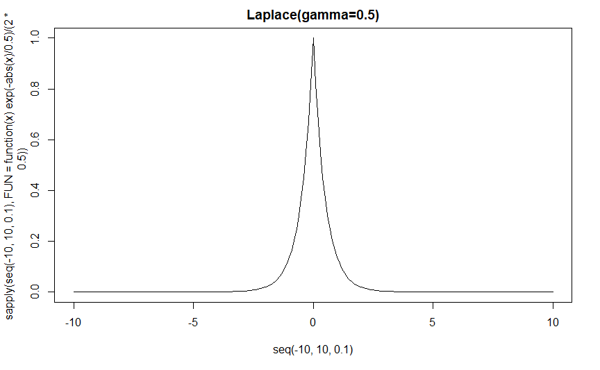

```r
plot(x=seq(-10,10,0.1), y = sapply(seq(-10,10,0.1), FUN = function(x) exp(-abs(x)/0.5)/(2*0.5)), type='l',main='Laplace(gamma=0.5)')
```

This is given by the following density function:

$$p(\beta|X) = p(\beta) = \prod_{k=1}^{K}{\frac{1}{2\gamma}e^{-\mid\beta\mid/{\gamma}}}$$
Which if set as the prior $p(\beta|X)$, results in the following:

$$\max_\beta{p(\beta|y,X)} = \max_\beta{p(y|beta,X)p(\beta|X)} \Rightarrow \\
= \min_\beta{\left[-\log{(p(y|\beta,X)p(\beta|X))}\right]} = \min_\beta\left[{-\log{(p(y|\beta,X))} -\log{(p(\beta|X))}}\right] \\
= \min_\beta{\left[ \frac{1}{2}\sum{\log{(2\pi)}} + \frac{1}{2}\epsilon^T\epsilon -\log{\left(\prod_{k=1}^{K}{\frac{1}{2\gamma}e^{-\mid\beta\mid/{\gamma}}}\right)} \right]} \\
= \min_\beta{\left[ \frac{1}{2}\sum{\log{(2\pi)}} + \frac{1}{2}\epsilon^T\epsilon -\sum_{k=1}^{K}{\log{\left(\frac{1}{2\gamma}e^{-\mid\beta\mid/{\gamma}}\right)}} \right]} \\
= \min_\beta{\left[ \frac{1}{2}\sum{\log{(2\pi)}} + \frac{1}{2}\epsilon^T\epsilon -\sum_{k=1}^{K}{\log{\left(\frac{1}{2\gamma}\right)}} -\sum_{k=1}^{K}{\log{\left(e^{-\mid\beta\mid/{\gamma}}\right)}} \right]} \\
= \min_\beta{\left[ \frac{1}{2}\sum{\log{(2\pi)}} + \frac{1}{2}\epsilon^T\epsilon -\sum_{k=1}^{K}{\log{\left(\frac{1}{2\gamma}\right)}} +\frac{1}{\gamma}\sum_{k=1}^{K}{\mid\beta\mid} \right]} \\
\leftrightarrow \beta^*=\arg\min_\beta{\left[ \frac{1}{2}\epsilon^T\epsilon +\frac{1}{\gamma}\sum_{k=1}^{K}{\mid\beta\mid} \right]}$$
When we minimize with respect to beta, the constants drop out, so we are left with minimizing $\min_\beta{\left[\epsilon^T\epsilon + (2/\gamma)\sum_{k=1}^{K}{\mid\beta\mid} \right]} \\$, which is equivalent to L1 Lasso regresion (where $2/\gamma$ is the regularization parameter). (Note that if we set the prior instead to the normal centered at zero, then we derive L2 ridge regression).

However, the ‘LASSO prior’ is not truly sparse when the likelihood function yields a non-zero coefficent. Although there is sparsity in the mode of the prior, when combining this with the likelihood distribution, the sparsity does not continue into the posterior distribution.

Consequently, we can combine a discrete and a continuous prior to construct a ‘spike-and-slab’ prior which fully zero-es out small coefficients:

# Spike-and-slab

We want to create a prior probability distribution that:

- Adds all the features into any model draw, with the coefficients being estimated through maximum likelihood
- For majority of these features, give them a prior that has a lot of probability mass around zero (a ‘spike’) to really shrink small coefficients - a form of ‘exclusion’
- For the rest of these features, gives them a prior thas is relatively uniform (a ‘slab’) to allow large coefficients to update with little shrinkage - a form of ‘inclusion’

One of the ways to achieve this is to create a prior that is a mixture of binary and continuous distribution, for example:

$$\beta = \gamma_iiZ_i \\
\text{where:} \\
\gamma_i \sim B(1,\pi_i) \\
Z_i \sim N(0,\sigma^2) \\
\frac{1}{\sigma^2} \sim \Gamma\left(\frac{df}{2},\frac{ss}{2}\right) \\$$

*(Spike-and-slab can be specified in many different ways, but we choose the one that is defined in BSTS here)*

Let’s break this down.

First let’s focus on $Z_i$. If we set a constant $\sigma^2=1$, then this is just a normal prior, and this on its own is equivalent to the prior for L2 ridge regression.

However, we want to form distribution that shrinks the coefficients less if there are larger:

- It needs to be consistently flatter at the sides, so that it is easier for evidence to update the posterior distribution if the coefficient is large rather than shrink towards the middle (zero)
- It needs to be suddenly steeper in the middle to push smaller coefficients towards zero

We can achieve this in part through setting the inverse of the variance of the normal distribution to a gamma distribution (we’ll go through the tau parameters in a mo).

This has a higher concentration around smaller values, pushing the general standard deviation to be tight around zero, but is more flat in its distribution of higher values. **It is this flatness that creates the ‘slab’**

```r
par(mfrow=c(1,3))
Zn = rnorm(n = 10^5, sd = 1)
tau = invgamma::rinvgamma(n = 10^5, shape = .15, scale = .15)
Z = rnorm(n = 10^5, sd = tau)
hist(Zn, main = 'N(0,1)',breaks=100)
hist(tau[tau < 10^5], main = 'Tau(.1,.1)',breaks=100)
```

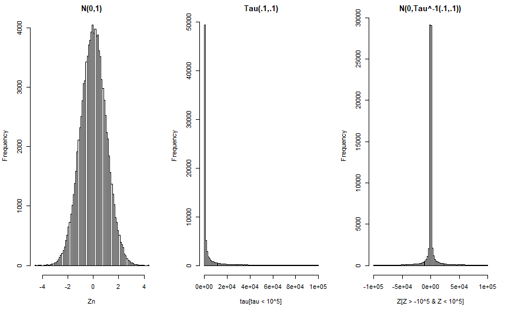

```r
hist(Z[Z>-10^5&Z<10^5], main = 'N(0,Tau^-1(.1,.1))',breaks=100)
```

This already looks a bit like a ‘spike-and-slab’ shape, kind of a steep laplace distribution, but there is still quite a bit of probability mass either side of zero that would be good to reduce if we want a much sparser data set: cue the bernoulli distribution $\gamma_i$:

$\gamma$ is a vector of zeros and ones, where ‘one’ implies the feature is included in the model, and ‘zero’ implies it is excluded, called $\gamma \in \{0,1\}$, where the probabitlity of inclusion $\pi(\gamma)$ follows a bernoulli distribution:

$$\pi(\gamma) \sim \prod_{k=1}^{K}{\pi_k^{\gamma_k}(1-\pi_k)^{1-\gamma_k}}$$

Without informative prior information, we tend to just set $\pi_k$ in the prior to a constant $\pi=\left(\frac{k}{K}\right)$, which yields:

$$\pi(\gamma) \sim \prod_{k=1}^{K}{\left(\frac{k}{K}\right)^{\gamma_k} \left( 1-\frac{k}{K} \right)^{1-\gamma_k}}$$

For example, if we have 50 possible candidates, and we believe 25 of them are likely to be relevant for the model, then we set $pi=\left(\frac{k}{K}\right)=\left(\frac{25}{50}\right)=0.5$. In other words, there is a 50% chance of any feature being used in any one model run.

We can see then that the value is 50%, the prior for beta will put a lot of probability mass at zero. **This creates a ‘spike’ around zero** regardless of the distribution of $Z_I$.

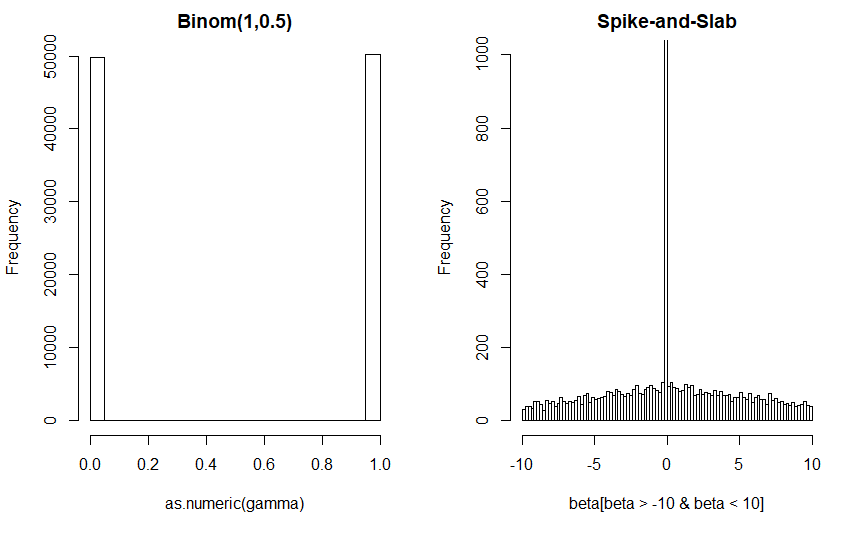

```r
gamma = rbinom(10^5,1,.5)
beta = gamma * Z
par(mfrow=c(1,2))
hist(as.numeric(gamma),main='Binom(1,0.5)')
hist(beta[beta>-10&beta<10],breaks=100,main='Spike-and-Slab',ylim=c(0,1000))
```

*In BSTS, the default shape parameter is $df/2$, where $df$ is just the number of data points. The rate parameter is $ss/2$, where $ss$ is the explained some of squares (which can be derived as $ss=df(1-R^2)s_y^2$). BSTS defaults the expected $R^2=0.5$.*

In practice, this happens many times with every draw of the model, and each time the potential coefficients are combined with the available data to make averaged predictions of the next period.